# LAB05-05_Pandas_introduction (ASSIGNMENT 5)

**What is Pandas?**

Pandas is an easy-to-use, very powerful library for data analysis. Like NumPy, it vectorises most of the basic operations and strives to excute multiple operations in parallel, even on a single CPU, resulting in faster computation.  
To use the pandas library and its data structures, all you have to do is to install it and import it. Refer to the documentation of the Pandas library for further details and guidance.  
https://pandas.pydata.org/

## Required libraries

Please make sure you have installed all the following packages:

- Python version 2.6-2.7 or 3.3-3.5
- Pandas version 0.18.0 or later: http://pandas.pydata.org/
- Numpy version 1.7 or later: http://www.numpy.org/
- matplotlib version 1.3 or later: http://matplotlib.org/
- ipython version 3.x with notebook support, or ipython 4.x combined with jupyter: http://ipython.org
- seaborn (this is used for some statistical data visualizations): http://stanford.edu/~mwaskom/software/seaborn/

## Let's set up the environment

```python
# %matplotlib is one of the magic functions
# With this, the output of plotting commands is displayed directly
# below the code cell that produced it. The resulting plots will then also
# be stored in the notebook document.
%matplotlib inline

import numpy as np
import pandas as pd
import matplotlib.pyplot as plt

pd.options.display.max_rows = 8
```

# 1. Let's start with a showcase

#### Case 1: titanic survival data

```python
# loading a file
df = pd.read_csv("data/titanic.csv")
```

```python
df.head()
```

|  | PassengerId | Survived | Pclass | Name | Sex | Age | SibSp | Parch | Ticket | Fare | Cabin | Embarked |
| --- | --- | --- | --- | --- | --- | --- | --- | --- | --- | --- | --- | --- |
| 0 | 1 | 0 | 3 | Braund, Mr. Owen Harris | male | 22.0 | 1 | 0 | A/5 21171 | 7.2500 | NaN | S |
| 1 | 2 | 1 | 1 | Cumings, Mrs. John Bradley (Florence Briggs Th... | female | 38.0 | 1 | 0 | PC 17599 | 71.2833 | C85 | C |
| 2 | 3 | 1 | 3 | Heikkinen, Miss. Laina | female | 26.0 | 0 | 0 | STON/O2. 3101282 | 7.9250 | NaN | S |
| 3 | 4 | 1 | 1 | Futrelle, Mrs. Jacques Heath (Lily May Peel) | female | 35.0 | 1 | 0 | 113803 | 53.1000 | C123 | S |
| 4 | 5 | 0 | 3 | Allen, Mr. William Henry | male | 35.0 | 0 | 0 | 373450 | 8.0500 | NaN | S |

Starting from reading this dataset, to answering questions about this data in a few lines of code:

**What is the age distribution of the passengers?**

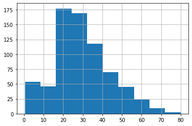

```python
df['Age'].hist()
```

**How does the survival rate of the passengers differ between sexes?**

```python
df.groupby('Sex')[['Survived']].aggregate(lambda x: x.sum() / len(x))
```

| Sex | Survived |
| --- | --- |
| female | 0.742038 |
| male | 0.188908 |

**Or how does it differ between the different classes?**

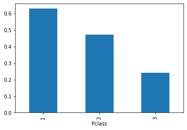

```python
df.groupby('Pclass')['Survived'].aggregate(lambda x: x.sum() / len(x)).plot(kind='bar')
```

All the needed functionality for the above examples will be explained throughout this tutorial.

# 2. Pandas: data analysis in python

For data-intensive work in Python the [Pandas](http://pandas.pydata.org) library has become essential.

What is `pandas`?

- Pandas can be thought of as *NumPy arrays with labels* for rows and columns, and better support for **heterogeneous data types**, but it's also much, much more than that.
- Pandas can also be thought of as `R`'s `data.frame` in Python.
- Powerful for working with **missing data**, working with **time series* data, for** reading and writing your data**, for** reshaping**,** grouping**,** merging** your data, ...

It's documentation: http://pandas.pydata.org/pandas-docs/stable/

### When do you need pandas?

When working with **tabular or structured data** (like R dataframe, SQL table, Excel spreadsheet, ...):

- Import data
- Clean up messy data
- Explore data, gain insight into data
- Process and prepare your data for analysis
- Analyse your data (together with scikit-learn, statsmodels, ...)

**ATTENTION!**:  
Pandas is great for working with heterogeneous and tabular 1D/2D data, but not all types of data fit in such structures!

- When working with **array data** (e.g. images, numerical algorithms): just **stick with numpy**
- When working with **multidimensional labeled data** (e.g. climate data): have a look at [xarray](http://xarray.pydata.org/en/stable/)

# 2. The pandas data structures: `DataFrame` and `Series`

A `DataFrame` is a **tablular data structure** (multi-dimensional object to hold labeled data) comprised of rows and columns, akin to a spreadsheet, database table, or R's data.frame object. You can think of it as multiple Series object which share the same index.

[figure not shown]

```python
df
```

|  | PassengerId | Survived | Pclass | Name | Sex | Age | SibSp | Parch | Ticket | Fare | Cabin | Embarked |
| --- | --- | --- | --- | --- | --- | --- | --- | --- | --- | --- | --- | --- |
| 0 | 1 | 0 | 3 | Braund, Mr. Owen Harris | male | 22.0 | 1 | 0 | A/5 21171 | 7.2500 | NaN | S |
| 1 | 2 | 1 | 1 | Cumings, Mrs. John Bradley (Florence Briggs Th... | female | 38.0 | 1 | 0 | PC 17599 | 71.2833 | C85 | C |
| 2 | 3 | 1 | 3 | Heikkinen, Miss. Laina | female | 26.0 | 0 | 0 | STON/O2. 3101282 | 7.9250 | NaN | S |
| 3 | 4 | 1 | 1 | Futrelle, Mrs. Jacques Heath (Lily May Peel) | female | 35.0 | 1 | 0 | 113803 | 53.1000 | C123 | S |
| ... | ... | ... | ... | ... | ... | ... | ... | ... | ... | ... | ... | ... |
| 887 | 888 | 1 | 1 | Graham, Miss. Margaret Edith | female | 19.0 | 0 | 0 | 112053 | 30.0000 | B42 | S |
| 888 | 889 | 0 | 3 | Johnston, Miss. Catherine Helen "Carrie" | female | NaN | 1 | 2 | W./C. 6607 | 23.4500 | NaN | S |
| 889 | 890 | 1 | 1 | Behr, Mr. Karl Howell | male | 26.0 | 0 | 0 | 111369 | 30.0000 | C148 | C |
| 890 | 891 | 0 | 3 | Dooley, Mr. Patrick | male | 32.0 | 0 | 0 | 370376 | 7.7500 | NaN | Q |

891 rows × 12 columns

### Attributes of the DataFrame

A DataFrame has an `index` attribute and a `columns` attribute:

```python
df.index
```

```
RangeIndex(start=0, stop=891, step=1)
```

```python
df.columns
```

```
Index(['PassengerId', 'Survived', 'Pclass', 'Name', 'Sex', 'Age', 'SibSp',
       'Parch', 'Ticket', 'Fare', 'Cabin', 'Embarked'],
      dtype='object')
```

To check the data types of the different columns:

```python
df.dtypes
```

```
PassengerId      int64
Survived         int64
Pclass           int64
Name            object
                ...
Ticket          object
Fare           float64
Cabin           object
Embarked        object
Length: 12, dtype: object
```

An overview of all the above information is given by the `info()` method:

```python
df.info()
```

```
<class 'pandas.core.frame.DataFrame'>
RangeIndex: 891 entries, 0 to 890
Data columns (total 12 columns):
PassengerId    891 non-null int64
Survived       891 non-null int64
Pclass         891 non-null int64
Name           891 non-null object
Sex            891 non-null object
Age            714 non-null float64
SibSp          891 non-null int64
Parch          891 non-null int64
Ticket         891 non-null object
Fare           891 non-null float64
Cabin          204 non-null object
Embarked       889 non-null object
dtypes: float64(2), int64(5), object(5)
memory usage: 83.7+ KB
```

Also a DataFrame has a `values` attribute, but attention: when you have heterogeneous data, all values will be upcasted:

```python
df.values
```

```
array([[1, 0, 3, ..., 7.25, nan, 'S'],
       [2, 1, 1, ..., 71.2833, 'C85', 'C'],
       [3, 1, 3, ..., 7.925, nan, 'S'],
       ...,
       [889, 0, 3, ..., 23.45, nan, 'S'],
       [890, 1, 1, ..., 30.0, 'C148', 'C'],
       [891, 0, 3, ..., 7.75, nan, 'Q']], dtype=object)
```

### You can also create a DataFrame from a list

Apart from importing your data from an external source (text file, excel, database, ..), one of the most common ways of creating a dataframe is from a **dictionary of arrays** or **lists**.

Note that in the IPython notebook, the dataframe will display in a rich HTML view:

```python
data = {'country': ['Belgium', 'France', 'Germany', 'Netherlands', 'United Kingdom'],
        'population': [11.3, 64.3, 81.3, 16.9, 64.9],
        'area': [30510, 671308, 357050, 41526, 244820],
        'capital': ['Brussels', 'Paris', 'Berlin', 'Amsterdam', 'London']}
df_countries = pd.DataFrame(data)
df_countries
```

|  | country | population | area | capital |
| --- | --- | --- | --- | --- |
| 0 | Belgium | 11.3 | 30510 | Brussels |
| 1 | France | 64.3 | 671308 | Paris |
| 2 | Germany | 81.3 | 357050 | Berlin |
| 3 | Netherlands | 16.9 | 41526 | Amsterdam |
| 4 | United Kingdom | 64.9 | 244820 | London |

### One-dimensional data: `Series` (a column of a DataFrame)

A Series is a basic holder for **one-dimensional labeled data**.

```python
df['Age']
```

```
0      22.0
1      38.0
2      26.0
3      35.0
       ...
887    19.0
888     NaN
889    26.0
890    32.0
Name: Age, Length: 891, dtype: float64
```

```python
age = df['Age']
type(age)
```

```
pandas.core.series.Series
```

### Attributes of a Series: `index` and `values`

The Series has also an `index` and `values` attribute, but no `columns`

```python
age.index
```

```
RangeIndex(start=0, stop=891, step=1)
```

You can access the underlying **numpy array** representation with the `.values` attribute:

```python
# extrecting the series as a NumPy array
age.values[:10]
```

```
array([22., 38., 26., 35., 35., nan, 54.,  2., 27., 14.])
```

We can access series values via the index, just like for NumPy arrays:

```python
age[0]
```

```
22.0
```

Unlike the NumPy array, though, this **index can be something other than integers**:

```python
# loading a file
df = pd.read_csv("data/titanic.csv")

# setting the index to the column ´Name´
df = df.set_index('Name')
df
```

| Name | PassengerId | Survived | Pclass | Sex | Age | SibSp | Parch | Ticket | Fare | Cabin | Embarked |
| --- | --- | --- | --- | --- | --- | --- | --- | --- | --- | --- | --- |
| Braund, Mr. Owen Harris | 1 | 0 | 3 | male | 22.0 | 1 | 0 | A/5 21171 | 7.2500 | NaN | S |
| Cumings, Mrs. John Bradley (Florence Briggs Thayer) | 2 | 1 | 1 | female | 38.0 | 1 | 0 | PC 17599 | 71.2833 | C85 | C |
| Heikkinen, Miss. Laina | 3 | 1 | 3 | female | 26.0 | 0 | 0 | STON/O2. 3101282 | 7.9250 | NaN | S |
| Futrelle, Mrs. Jacques Heath (Lily May Peel) | 4 | 1 | 1 | female | 35.0 | 1 | 0 | 113803 | 53.1000 | C123 | S |
| ... | ... | ... | ... | ... | ... | ... | ... | ... | ... | ... | ... |
| Graham, Miss. Margaret Edith | 888 | 1 | 1 | female | 19.0 | 0 | 0 | 112053 | 30.0000 | B42 | S |
| Johnston, Miss. Catherine Helen "Carrie" | 889 | 0 | 3 | female | NaN | 1 | 2 | W./C. 6607 | 23.4500 | NaN | S |
| Behr, Mr. Karl Howell | 890 | 1 | 1 | male | 26.0 | 0 | 0 | 111369 | 30.0000 | C148 | C |
| Dooley, Mr. Patrick | 891 | 0 | 3 | male | 32.0 | 0 | 0 | 370376 | 7.7500 | NaN | Q |

891 rows × 11 columns

```python
age = df['Age']
age
```

```
Name
Braund, Mr. Owen Harris                                22.0
Cumings, Mrs. John Bradley (Florence Briggs Thayer)    38.0
Heikkinen, Miss. Laina                                 26.0
Futrelle, Mrs. Jacques Heath (Lily May Peel)           35.0
                                                       ...
Graham, Miss. Margaret Edith                           19.0
Johnston, Miss. Catherine Helen "Carrie"                NaN
Behr, Mr. Karl Howell                                  26.0
Dooley, Mr. Patrick                                    32.0
Name: Age, Length: 891, dtype: float64
```

```python
age['Dooley, Mr. Patrick']
```

```
32.0
```

### Pandas can do many things like NumPy arrays

Many things you can do with numpy arrays, can also be applied on DataFrames / Series.

E.g. element-wise operations:

```python
age * 1000
```

```
Name
Braund, Mr. Owen Harris                                22000.0
Cumings, Mrs. John Bradley (Florence Briggs Thayer)    38000.0
Heikkinen, Miss. Laina                                 26000.0
Futrelle, Mrs. Jacques Heath (Lily May Peel)           35000.0
                                                        ...
Graham, Miss. Margaret Edith                           19000.0
Johnston, Miss. Catherine Helen "Carrie"                   NaN
Behr, Mr. Karl Howell                                  26000.0
Dooley, Mr. Patrick                                    32000.0
Name: Age, Length: 891, dtype: float64
```

A range of methods:

```python
age.mean()
```

```
29.69911764705882
```

Fancy indexing, like indexing with a list or boolean indexing:

```python
# filtering out the younger passengers
age[age > 70]
```

```
Name
Goldschmidt, Mr. George B               71.0
Connors, Mr. Patrick                    70.5
Artagaveytia, Mr. Ramon                 71.0
Barkworth, Mr. Algernon Henry Wilson    80.0
Svensson, Mr. Johan                     74.0
Name: Age, dtype: float64
```

### There are also some Panda specific methods

For example:

```python
df['Embarked'].value_counts()
```

```
S    644
C    168
Q     77
Name: Embarked, dtype: int64
```

**EXERCISE**:

```python
# write your code here
df['Fare'].mean()
```

```
32.204207968574636
```

```python
# write your code here
df['Fare'].median()
```

```
14.4542
```

**EXERCISE**:

- Calculate the average survival ratio for all passengers (note: the 'Survived' column indicates whether someone survived (1) or not (0)).

```python
# d# write your code here
df['Survived'].mean()
```

```
0.3838383838383838
```

# 3. Data import and export

A wide range of input/output formats are natively supported by pandas:

- CSV (comma separated values)
- text
- SQL database
- Excel
- HDF5
- json
- html
- pickle
- sas, stata
- (parquet)
- ...

Very powerful csv reader:

```python
# loads of arguments may be used automatically when importing from a .csv file.
pd.read_csv
```

```
<function pandas.io.parsers._make_parser_function.<locals>.parser_f(filepath_or_buffer: Union[str, pathlib.Path, IO[~AnyStr]], sep=',', delimiter=None, header='infer', names=None, index_col=None, usecols=None, squeeze=False, prefix=None, mangle_dupe_cols=True, dtype=None, engine=None, converters=Non…
```

Luckily, if we have a well formed csv file, we don't need many of those arguments:

```python
df = pd.read_csv("data/titanic.csv")
```

```python
df.head()
```

|  | PassengerId | Survived | Pclass | Name | Sex | Age | SibSp | Parch | Ticket | Fare | Cabin | Embarked |
| --- | --- | --- | --- | --- | --- | --- | --- | --- | --- | --- | --- | --- |
| 0 | 1 | 0 | 3 | Braund, Mr. Owen Harris | male | 22.0 | 1 | 0 | A/5 21171 | 7.2500 | NaN | S |
| 1 | 2 | 1 | 1 | Cumings, Mrs. John Bradley (Florence Briggs Th... | female | 38.0 | 1 | 0 | PC 17599 | 71.2833 | C85 | C |
| 2 | 3 | 1 | 3 | Heikkinen, Miss. Laina | female | 26.0 | 0 | 0 | STON/O2. 3101282 | 7.9250 | NaN | S |
| 3 | 4 | 1 | 1 | Futrelle, Mrs. Jacques Heath (Lily May Peel) | female | 35.0 | 1 | 0 | 113803 | 53.1000 | C123 | S |
| 4 | 5 | 0 | 3 | Allen, Mr. William Henry | male | 35.0 | 0 | 0 | 373450 | 8.0500 | NaN | S |

**EXERCISE**: Read the `data/20000101_20161231-NO2.csv` file into a DataFrame `no2`  
Check the documentation at: https://pandas.pydata.org/pandas-docs/stable/reference/api/pandas.read_csv.html  
Some aspects about the file:

- Which separator is used in the file?
- The second row includes unit information and should be skipped (check `skiprows` keyword)
- For missing values, it uses the `'n/d'` notation (check `na_values` keyword)
- We want to parse the 'timestamp' column as datetimes (check the `parse_dates` keyword)

```python
# the raw cvs file has all in a single column but we can see that ";" is used as separator
nx = pd.read_csv('data/20000101_20161231-NO2.csv')
nx
```

|  | timestamp;BASCH;BONAP;PA18;VERS |
| --- | --- |
| 0 | ;microg/m3;microg/m3;microg/m3;microg/m3 |
| 1 | 2000-01-01 01:00:00;108.0;n/d;65.0;47.0 |
| 2 | 2000-01-01 02:00:00;104.0;60.0;77.0;42.0 |
| 3 | 2000-01-01 03:00:00;97.0;58.0;73.0;34.0 |
| ... | ... |
| 149036 | 2016-12-31 20:00:00;73.0;51.0;49.0;20.0 |
| 149037 | 2016-12-31 21:00:00;61.0;51.0;48.0;16.0 |
| 149038 | 2016-12-31 22:00:00;57.0;49.0;45.0;14.0 |
| 149039 | 2016-12-31 23:00:00;51.0;47.0;45.0;12.0 |

149040 rows × 1 columns

```python
# let's creat separate columns using ; as the separator
# we skip the second row which includes descriptive unit information
# We are standardizing the null values using the NaN keyword
# setting the first colum as index
# we parse the 'timestamp' column as datetimes
no2 = pd.read_csv('data/20000101_20161231-NO2.csv', sep=';', skiprows=[1], na_values=['n/d'], index_col=0, parse_dates=True)
no2
```

| timestamp | BASCH | BONAP | PA18 | VERS |
| --- | --- | --- | --- | --- |
| 2000-01-01 01:00:00 | 108.0 | NaN | 65.0 | 47.0 |
| 2000-01-01 02:00:00 | 104.0 | 60.0 | 77.0 | 42.0 |
| 2000-01-01 03:00:00 | 97.0 | 58.0 | 73.0 | 34.0 |
| 2000-01-01 04:00:00 | 77.0 | 52.0 | 57.0 | 29.0 |
| ... | ... | ... | ... | ... |
| 2016-12-31 20:00:00 | 73.0 | 51.0 | 49.0 | 20.0 |
| 2016-12-31 21:00:00 | 61.0 | 51.0 | 48.0 | 16.0 |
| 2016-12-31 22:00:00 | 57.0 | 49.0 | 45.0 | 14.0 |
| 2016-12-31 23:00:00 | 51.0 | 47.0 | 45.0 | 12.0 |

149039 rows × 4 columns

# 4. Exploration

Some useful methods:

`head` and `tail`

```python
no2.head(3)
```

| timestamp | BASCH | BONAP | PA18 | VERS |
| --- | --- | --- | --- | --- |
| 2000-01-01 01:00:00 | 108.0 | NaN | 65.0 | 47.0 |
| 2000-01-01 02:00:00 | 104.0 | 60.0 | 77.0 | 42.0 |
| 2000-01-01 03:00:00 | 97.0 | 58.0 | 73.0 | 34.0 |

```python
no2.tail()
```

| timestamp | BASCH | BONAP | PA18 | VERS |
| --- | --- | --- | --- | --- |
| 2016-12-31 19:00:00 | 77.0 | 49.0 | 52.0 | 23.0 |
| 2016-12-31 20:00:00 | 73.0 | 51.0 | 49.0 | 20.0 |
| 2016-12-31 21:00:00 | 61.0 | 51.0 | 48.0 | 16.0 |
| 2016-12-31 22:00:00 | 57.0 | 49.0 | 45.0 | 14.0 |
| 2016-12-31 23:00:00 | 51.0 | 47.0 | 45.0 | 12.0 |

`info()`

```python
no2.info()
```

```
<class 'pandas.core.frame.DataFrame'>
DatetimeIndex: 149039 entries, 2000-01-01 01:00:00 to 2016-12-31 23:00:00
Data columns (total 4 columns):
BASCH    139949 non-null float64
BONAP    136493 non-null float64
PA18     142259 non-null float64
VERS     143813 non-null float64
dtypes: float64(4)
memory usage: 5.7 MB
```

Getting some basic summary statistics about the data with `describe`:

```python
no2.describe()
```

|  | BASCH | BONAP | PA18 | VERS |
| --- | --- | --- | --- | --- |
| count | 139949.000000 | 136493.000000 | 142259.000000 | 143813.000000 |
| mean | 89.270098 | 64.001714 | 45.104211 | 27.613227 |
| std | 36.772855 | 27.866767 | 23.212719 | 19.604953 |
| min | 4.000000 | 0.000000 | 2.000000 | 0.000000 |
| 25% | 63.000000 | 44.000000 | 28.000000 | 13.000000 |
| 50% | 87.000000 | 62.000000 | 42.000000 | 22.000000 |
| 75% | 112.000000 | 81.000000 | 59.000000 | 38.000000 |
| max | 358.000000 | 345.000000 | 306.000000 | 197.000000 |

Quickly visualizing the data

## Exercise

The following operation may generate warning or an error (depending on your version).

- Looking through the documentation, find out how to fix this warning. Write your code below the next cell.

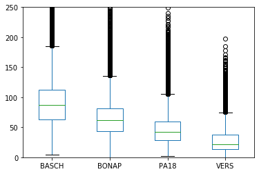

```python
no2.plot(kind='box', ylim=[0,250])
```

```python
# write your code here

## no warning for me
```

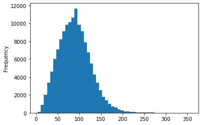

```python
no2['BASCH'].plot(kind='hist', bins=50)
```

**EXERCISE**:

- Plot the age distribution of the titanic passengers

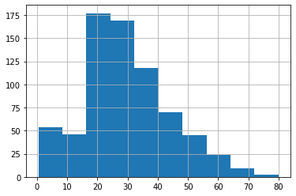

```python
# write your code here

df['Age'].hist()
```

The default plot (when not specifying `kind`) is a line plot of all columns:

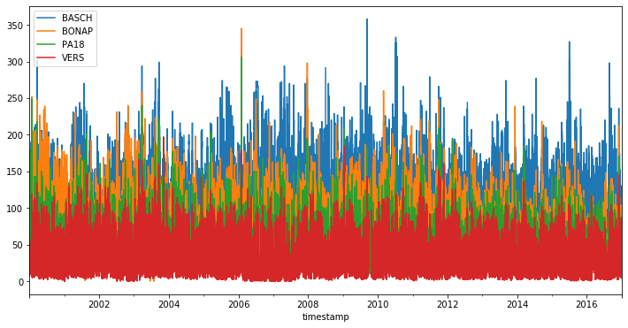

```python
no2.plot(figsize=(12,6))
```

This does not say too much ..

We can select part of the data (eg the latest 500 data points):

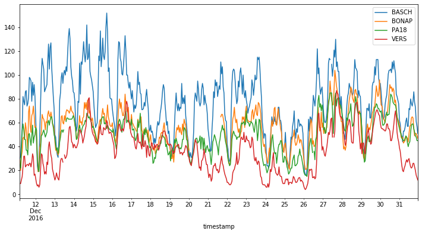

```python
# remember slicing? negative numbers get you started from the end of the list
no2[-500:].plot(figsize=(12,6))
```

Or we can use some more advanced time series features -> see further in this notebook!

# 5. Selecting and filtering data

**ATTENTION!**:  
One of pandas' basic features is the labeling of rows and columns, but this makes indexing also a bit more complex compared to numpy.  
We now have to distuinguish between:

- selection by **label**
- selection by **position**

```python
df = pd.read_csv("data/titanic.csv")
```

### `df[]` provides some convenience shortcuts

For a DataFrame, basic indexing selects the columns.

Selecting a single column:

```python
df['Age']
```

```
0      22.0
1      38.0
2      26.0
3      35.0
       ...
887    19.0
888     NaN
889    26.0
890    32.0
Name: Age, Length: 891, dtype: float64
```

or multiple columns:

```python
df[['Age', 'Fare']]
```

|  | Age | Fare |
| --- | --- | --- |
| 0 | 22.0 | 7.2500 |
| 1 | 38.0 | 71.2833 |
| 2 | 26.0 | 7.9250 |
| 3 | 35.0 | 53.1000 |
| ... | ... | ... |
| 887 | 19.0 | 30.0000 |
| 888 | NaN | 23.4500 |
| 889 | 26.0 | 30.0000 |
| 890 | 32.0 | 7.7500 |

891 rows × 2 columns

But, **slicing accesses the rows!**

```python
df[10:15]
```

|  | PassengerId | Survived | Pclass | Name | Sex | Age | SibSp | Parch | Ticket | Fare | Cabin | Embarked |
| --- | --- | --- | --- | --- | --- | --- | --- | --- | --- | --- | --- | --- |
| 10 | 11 | 1 | 3 | Sandstrom, Miss. Marguerite Rut | female | 4.0 | 1 | 1 | PP 9549 | 16.7000 | G6 | S |
| 11 | 12 | 1 | 1 | Bonnell, Miss. Elizabeth | female | 58.0 | 0 | 0 | 113783 | 26.5500 | C103 | S |
| 12 | 13 | 0 | 3 | Saundercock, Mr. William Henry | male | 20.0 | 0 | 0 | A/5. 2151 | 8.0500 | NaN | S |
| 13 | 14 | 0 | 3 | Andersson, Mr. Anders Johan | male | 39.0 | 1 | 5 | 347082 | 31.2750 | NaN | S |
| 14 | 15 | 0 | 3 | Vestrom, Miss. Hulda Amanda Adolfina | female | 14.0 | 0 | 0 | 350406 | 7.8542 | NaN | S |

### Systematic indexing with `loc` and `iloc`

When using `[]` like above, you can only select from one axis at once (rows or columns, not both). For more advanced indexing, you have some extra attributes:

- `loc`: selection by **label** (name)
- `iloc`: selection by **position** (integer)

These methods index the different dimensions of the frame:

- `df.loc[row_indexer, column_indexer]`
- `df.iloc[row_indexer, column_indexer]`

```python
df = df.set_index('Name')
```

```python
df.loc['Bonnell, Miss. Elizabeth', 'Fare']
```

```
26.55
```

**The row or column indexer can also be a list, slice, boolean array, ..**

```python
# select a range in the rows. The : indicates that we are selecting all columns
df.loc['Bonnell, Miss. Elizabeth':'Andersson, Mr. Anders Johan', :]
```

| Name | PassengerId | Survived | Pclass | Sex | Age | SibSp | Parch | Ticket | Fare | Cabin | Embarked |
| --- | --- | --- | --- | --- | --- | --- | --- | --- | --- | --- | --- |
| Bonnell, Miss. Elizabeth | 12 | 1 | 1 | female | 58.0 | 0 | 0 | 113783 | 26.550 | C103 | S |
| Saundercock, Mr. William Henry | 13 | 0 | 3 | male | 20.0 | 0 | 0 | A/5. 2151 | 8.050 | NaN | S |
| Andersson, Mr. Anders Johan | 14 | 0 | 3 | male | 39.0 | 1 | 5 | 347082 | 31.275 | NaN | S |

Selecting by position with **`iloc` works similar to indexing numpy arrays**

```python
# selecting 1st and second rows, and 2nd and 3rd column from the whole dataset
df.iloc[0:2,1:3]
```

| Name | Survived | Pclass |
| --- | --- | --- |
| Braund, Mr. Owen Harris | 0 | 3 |
| Cumings, Mrs. John Bradley (Florence Briggs Thayer) | 1 | 1 |

The different indexing methods can also be used to assign data:

```python
df.loc['Braund, Mr. Owen Harris', 'Survived'] = 100
```

```python
df
```

| Name | PassengerId | Survived | Pclass | Sex | Age | SibSp | Parch | Ticket | Fare | Cabin | Embarked |
| --- | --- | --- | --- | --- | --- | --- | --- | --- | --- | --- | --- |
| Braund, Mr. Owen Harris | 1 | 100 | 3 | male | 22.0 | 1 | 0 | A/5 21171 | 7.2500 | NaN | S |
| Cumings, Mrs. John Bradley (Florence Briggs Thayer) | 2 | 1 | 1 | female | 38.0 | 1 | 0 | PC 17599 | 71.2833 | C85 | C |
| Heikkinen, Miss. Laina | 3 | 1 | 3 | female | 26.0 | 0 | 0 | STON/O2. 3101282 | 7.9250 | NaN | S |
| Futrelle, Mrs. Jacques Heath (Lily May Peel) | 4 | 1 | 1 | female | 35.0 | 1 | 0 | 113803 | 53.1000 | C123 | S |
| ... | ... | ... | ... | ... | ... | ... | ... | ... | ... | ... | ... |
| Graham, Miss. Margaret Edith | 888 | 1 | 1 | female | 19.0 | 0 | 0 | 112053 | 30.0000 | B42 | S |
| Johnston, Miss. Catherine Helen "Carrie" | 889 | 0 | 3 | female | NaN | 1 | 2 | W./C. 6607 | 23.4500 | NaN | S |
| Behr, Mr. Karl Howell | 890 | 1 | 1 | male | 26.0 | 0 | 0 | 111369 | 30.0000 | C148 | C |
| Dooley, Mr. Patrick | 891 | 0 | 3 | male | 32.0 | 0 | 0 | 370376 | 7.7500 | NaN | Q |

891 rows × 11 columns

### Boolean indexing (filtering)

Often, you want to select rows based on a certain condition. This can be done with 'boolean indexing' (like a where clause in SQL) and comparable to numpy.

The indexer (or boolean mask) should be 1-dimensional and the same length as the thing being indexed.

```python
# checking True and False values
df['Fare'] > 50
```

```
Name
Braund, Mr. Owen Harris                                False
Cumings, Mrs. John Bradley (Florence Briggs Thayer)     True
Heikkinen, Miss. Laina                                 False
Futrelle, Mrs. Jacques Heath (Lily May Peel)            True
                                                       ...
Graham, Miss. Margaret Edith                           False
Johnston, Miss. Catherine Helen "Carrie"               False
Behr, Mr. Karl Howell                                  False
Dooley, Mr. Patrick                                    False
Name: Fare, Length: 891, dtype: bool
```

```python
# selecting only the True values
# that's all the lines where Fare is > 50
df[df['Fare'] > 50]
```

| Name | PassengerId | Survived | Pclass | Sex | Age | SibSp | Parch | Ticket | Fare | Cabin | Embarked |
| --- | --- | --- | --- | --- | --- | --- | --- | --- | --- | --- | --- |
| Cumings, Mrs. John Bradley (Florence Briggs Thayer) | 2 | 1 | 1 | female | 38.0 | 1 | 0 | PC 17599 | 71.2833 | C85 | C |
| Futrelle, Mrs. Jacques Heath (Lily May Peel) | 4 | 1 | 1 | female | 35.0 | 1 | 0 | 113803 | 53.1000 | C123 | S |
| McCarthy, Mr. Timothy J | 7 | 0 | 1 | male | 54.0 | 0 | 0 | 17463 | 51.8625 | E46 | S |
| Fortune, Mr. Charles Alexander | 28 | 0 | 1 | male | 19.0 | 3 | 2 | 19950 | 263.0000 | C23 C25 C27 | S |
| ... | ... | ... | ... | ... | ... | ... | ... | ... | ... | ... | ... |
| Sage, Miss. Dorothy Edith "Dolly" | 864 | 0 | 3 | female | NaN | 8 | 2 | CA. 2343 | 69.5500 | NaN | S |
| Roebling, Mr. Washington Augustus II | 868 | 0 | 1 | male | 31.0 | 0 | 0 | PC 17590 | 50.4958 | A24 | S |
| Beckwith, Mrs. Richard Leonard (Sallie Monypeny) | 872 | 1 | 1 | female | 47.0 | 1 | 1 | 11751 | 52.5542 | D35 | S |
| Potter, Mrs. Thomas Jr (Lily Alexenia Wilson) | 880 | 1 | 1 | female | 56.0 | 0 | 1 | 11767 | 83.1583 | C50 | C |

160 rows × 11 columns

**EXERCISE**:

- Based on the titanic data set, select all rows for male passengers and calculate the mean age of those passengers. Do the same for the female passengers

```python
df = pd.read_csv("data/titanic.csv")
```

```python
# write your code here
df[df['Sex'] == 'male']['Age'].mean()
```

```
30.72664459161148
```

```python
# write your code here
df[df['Sex'] == 'female']['Age'].mean()
```

```
27.915708812260537
```

**EXERCISE**:

- Based on the titanic data set, how many passengers older than 70 were on the Titanic?

```python
# write your code here
sum(df['Age'] > 70)
```

```
5
```

# 6. The group-by operation

### Some 'theory': the groupby operation (split-apply-combine)

```python
df = pd.DataFrame({'key':['A','B','C','A','B','C','A','B','C'],
                   'data': [0, 5, 10, 5, 10, 15, 10, 15, 20]})
df
```

|  | key | data |
| --- | --- | --- |
| 0 | A | 0 |
| 1 | B | 5 |
| 2 | C | 10 |
| 3 | A | 5 |
| ... | ... | ... |
| 5 | C | 15 |
| 6 | A | 10 |
| 7 | B | 15 |
| 8 | C | 20 |

9 rows × 2 columns

### Recap: aggregating functions

When analyzing data, you often calculate summary statistics (aggregations like the mean, max, ...). As we have seen before, we can easily calculate statistics for a Series or column using one of the many available methods. For example:

```python
df['data'].sum()
```

```
90
```

However, in many cases your data has certain groups in it, and in that case, you may want to **calculate this statistic for each of the groups**.

For example, in the above dataframe `df`, there is a column 'key' which has three possible values: 'A', 'B' and 'C'. When we want to calculate the sum for each of those groups, we could do the following:

```python
# this is a verbose version of working on groups (not really the best)
for key in ['A', 'B', 'C']:
    print(key, df[df['key'] == key]['data'].sum())
```

```
A 15
B 30
C 45
```

This becomes very verbose when having multiple groups. You could make the above a bit easier by looping over the different values, but still, it is not very convenient to work with.

What we did above, applying a function on different groups, is a **groupby operation**, and pandas provides some convenient functionality for this.

### Groupby: applying functions per group

The "group by" concept: we want to **apply the same function on subsets of your dataframe, based on some key to split the dataframe in subsets**

This operation is also referred to as the "split-apply-combine" operation, involving the following steps:

- **Splitting** the data into groups based on some criteria
- **Applying** a function to each group independently
- **Combining** the results into a data structure

[figure not shown]

Similar to SQL `GROUP BY`

Instead of doing the manual filtering as above

```
df[df['key'] == "A"].sum()
df[df['key'] == "B"].sum()
...
```

pandas provides the `groupby` method to do exactly this:

```python
# simplest way to work on groups
df.groupby('key').sum()
```

| key | data |
| --- | --- |
| A | 15 |
| B | 30 |
| C | 45 |

```python
# another way to obtain the same
df.groupby('key').aggregate(np.sum)  # 'sum'
```

| key | data |
| --- | --- |
| A | 15 |
| B | 30 |
| C | 45 |

And many more methods are available.

```python
df.groupby('key')['data'].sum()
```

```
key
A    15
B    30
C    45
Name: data, dtype: int64
```

### Application of the groupby concept on the titanic data

We go back to the titanic passengers survival data:

```python
df = pd.read_csv("data/titanic.csv")
```

```python
df.head()
```

|  | PassengerId | Survived | Pclass | Name | Sex | Age | SibSp | Parch | Ticket | Fare | Cabin | Embarked |
| --- | --- | --- | --- | --- | --- | --- | --- | --- | --- | --- | --- | --- |
| 0 | 1 | 0 | 3 | Braund, Mr. Owen Harris | male | 22.0 | 1 | 0 | A/5 21171 | 7.2500 | NaN | S |
| 1 | 2 | 1 | 1 | Cumings, Mrs. John Bradley (Florence Briggs Th... | female | 38.0 | 1 | 0 | PC 17599 | 71.2833 | C85 | C |
| 2 | 3 | 1 | 3 | Heikkinen, Miss. Laina | female | 26.0 | 0 | 0 | STON/O2. 3101282 | 7.9250 | NaN | S |
| 3 | 4 | 1 | 1 | Futrelle, Mrs. Jacques Heath (Lily May Peel) | female | 35.0 | 1 | 0 | 113803 | 53.1000 | C123 | S |
| 4 | 5 | 0 | 3 | Allen, Mr. William Henry | male | 35.0 | 0 | 0 | 373450 | 8.0500 | NaN | S |

**EXERCISE**:

- Calculate the average age for each sex again, but now using groupby.

```python
# write your code here
df.groupby('Sex')['Age'].mean()
```

```
Sex
female    27.915709
male      30.726645
Name: Age, dtype: float64
```

**EXERCISE**:

- Calculate the average survival ratio for all passengers.

```python
# write your code here
df['Survived'].mean()
```

```
0.3838383838383838
```

**EXERCISE**:

- Calculate this survival ratio for all passengers younger that 25 (remember: filtering/boolean indexing).

```python
# write your code here

df[df['Age'] < 25]['Survived'].mean()
```

```
0.4244604316546763
```

**EXERCISE**:

- What is the difference in the survival ratio between the sexes?

```python
# write your code here

df.groupby('Sex')['Survived'].mean()
```

```
Sex
female    0.742038
male      0.188908
Name: Survived, dtype: float64
```

**EXERCISE**:

- Or how does it differ between the different classes? Make a bar plot visualizing the survival ratio for the 3 classes.

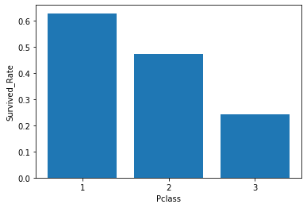

```python
# write your code here
df['Pclass'] = df['Pclass'].astype(str)

pclass_mean_surv = df.groupby('Pclass')['Survived'].mean()

plt.bar(pclass_mean_surv.index, pclass_mean_surv.values)
plt.xlabel('Pclass')
plt.ylabel('Survived_Rate')
```

**EXERCISE**:

- Make a bar plot to visualize the average Fare payed by people depending on their age. The age column is devided is separate classes using the `pd.cut` function as provided below.

```python
df['AgeClass'] = pd.cut(df['Age'], bins=np.arange(0,90,10))
```

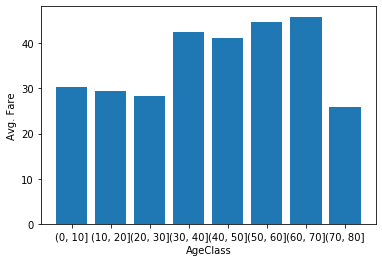

```python
# write your code here

mean_fare = df.groupby('AgeClass')['Fare'].mean()

plt.bar(mean_fare.index.astype(str), mean_fare.values)
plt.xlabel('AgeClass')
plt.ylabel('Avg. Fare')
```

# 7. Working with time series data

```python
no2 = pd.read_csv('data/20000101_20161231-NO2.csv', sep=';', skiprows=[1], na_values=['n/d'], index_col=0, parse_dates=True)
```

When we ensure the DataFrame has a `DatetimeIndex`, time-series related functionality becomes available:

```python
no2.index
```

```
DatetimeIndex(['2000-01-01 01:00:00', '2000-01-01 02:00:00',
               '2000-01-01 03:00:00', '2000-01-01 04:00:00',
               '2000-01-01 05:00:00', '2000-01-01 06:00:00',
               '2000-01-01 07:00:00', '2000-01-01 08:00:00',
               '2000-01-01 09:00:00', '2000-01-01 10:00:00',
               ...
               '2016-12-31 14:00:00', '2016-12-31 15:00:00',
               '2016-12-31 16:00:00', '2016-12-31 17:00:00',
               '2016-12-31 18:00:00', '2016-12-31 19:00:00',
               '2016-12-31 20:00:00', '2016-12-31 21:00:00',
               '2016-12-31 22:00:00', '2016-12-31 23:00:00'],
              dtype='datetime64[ns]', name='timestamp', length=149039, freq=None)
```

Indexing a time series works with strings:

```python
# select entries between 9am and 12noon
no2["2010-01-01 09:00": "2010-01-01 12:00"]
```

| timestamp | BASCH | BONAP | PA18 | VERS |
| --- | --- | --- | --- | --- |
| 2010-01-01 09:00:00 | 31.0 | 27.0 | 28.0 | 14.0 |
| 2010-01-01 10:00:00 | 41.0 | 31.0 | 30.0 | 14.0 |
| 2010-01-01 11:00:00 | 48.0 | 32.0 | 33.0 | 16.0 |
| 2010-01-01 12:00:00 | 63.0 | 33.0 | 39.0 | 19.0 |

A nice feature is "partial string" indexing, so you don't need to provide the full datetime string.

E.g. all data of January up to March 2012:

```python
no2['2012-01':'2012-03']
```

| timestamp | BASCH | BONAP | PA18 | VERS |
| --- | --- | --- | --- | --- |
| 2012-01-01 00:00:00 | 44.0 | 34.0 | 32.0 | 7.0 |
| 2012-01-01 01:00:00 | 56.0 | 35.0 | 29.0 | 9.0 |
| 2012-01-01 02:00:00 | 50.0 | 36.0 | 29.0 | 7.0 |
| 2012-01-01 03:00:00 | 46.0 | 34.0 | 22.0 | 8.0 |
| ... | ... | ... | ... | ... |
| 2012-03-31 20:00:00 | 61.0 | 55.0 | 29.0 | 17.0 |
| 2012-03-31 21:00:00 | 46.0 | 49.0 | 32.0 | 14.0 |
| 2012-03-31 22:00:00 | 56.0 | 41.0 | 27.0 | 14.0 |
| 2012-03-31 23:00:00 | 59.0 | 51.0 | 29.0 | 13.0 |

2184 rows × 4 columns

Time and date components can be accessed from the index:

```python
no2.index.hour
```

```
Int64Index([ 1,  2,  3,  4,  5,  6,  7,  8,  9, 10,
            ...
            14, 15, 16, 17, 18, 19, 20, 21, 22, 23],
           dtype='int64', name='timestamp', length=149039)
```

```python
no2.index.year
```

```
Int64Index([2000, 2000, 2000, 2000, 2000, 2000, 2000, 2000, 2000, 2000,
            ...
            2016, 2016, 2016, 2016, 2016, 2016, 2016, 2016, 2016, 2016],
           dtype='int64', name='timestamp', length=149039)
```

## Converting your time series with `resample`

A very powerfull method is **`resample`: converting the frequency of the time series** (e.g. from hourly to daily data).

Remember the air quality data:

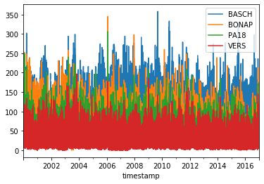

```python
no2.plot()
```

The time series has a frequency of 1 hour. I want to change this to daily:

```python
no2.head()
```

| timestamp | BASCH | BONAP | PA18 | VERS |
| --- | --- | --- | --- | --- |
| 2000-01-01 01:00:00 | 108.0 | NaN | 65.0 | 47.0 |
| 2000-01-01 02:00:00 | 104.0 | 60.0 | 77.0 | 42.0 |
| 2000-01-01 03:00:00 | 97.0 | 58.0 | 73.0 | 34.0 |
| 2000-01-01 04:00:00 | 77.0 | 52.0 | 57.0 | 29.0 |
| 2000-01-01 05:00:00 | 79.0 | 52.0 | 64.0 | 28.0 |

```python
no2.resample('D').mean().head()
```

| timestamp | BASCH | BONAP | PA18 | VERS |
| --- | --- | --- | --- | --- |
| 2000-01-01 | 83.173913 | 53.772727 | 64.695652 | 36.521739 |
| 2000-01-02 | 78.708333 | 59.250000 | 63.708333 | 17.166667 |
| 2000-01-03 | 82.333333 | 73.541667 | 61.000000 | 23.083333 |
| 2000-01-04 | 78.500000 | 73.708333 | 48.863636 | 23.791667 |
| 2000-01-05 | 94.291667 | 90.458333 | 60.166667 | 28.214286 |

Above I take the mean, but as with `groupby` I can also specify other methods:

```python
# sampling on the day (it's like grouping by day)
no2.resample('D').max().head()
```

| timestamp | BASCH | BONAP | PA18 | VERS |
| --- | --- | --- | --- | --- |
| 2000-01-01 | 109.0 | 62.0 | 77.0 | 59.0 |
| 2000-01-02 | 109.0 | 96.0 | 78.0 | 45.0 |
| 2000-01-03 | 120.0 | 102.0 | 72.0 | 37.0 |
| 2000-01-04 | 115.0 | 107.0 | 78.0 | 43.0 |
| 2000-01-05 | 141.0 | 115.0 | 82.0 | 41.0 |

The string to specify the new time frequency: http://pandas.pydata.org/pandas-docs/dev/timeseries.html#offset-aliases  
These strings can also be combined with numbers, eg `'10D'`.

Further exploring the data:

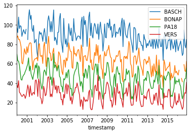

```python
# sampling on the month
no2.resample('M').mean().plot() # 'A'
```

[output not shown]

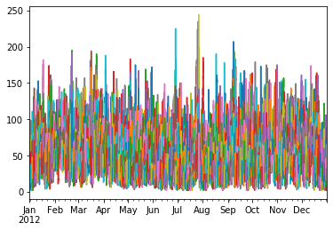

```python
# sampling on every day of 2012
# this will take quite a bit of time to execute
no2['2012'].resample('D').plot()
```

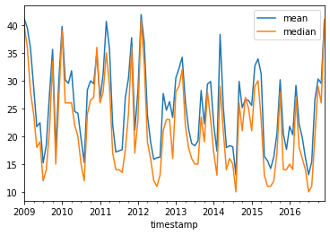

```python
# locs on 2009, the VERS column, resamples by month and then shows mean and median
no2.loc['2009':, 'VERS'].resample('M').agg(['mean', 'median']).plot()
```

**EXERCISE**: The evolution of the yearly averages with, and the overall mean of all stations

- Use `resample` and `plot` to plot the yearly averages for the different stations.
- The overall mean of all stations can be calculated by taking the mean of the different columns (`.mean(axis=1)`).

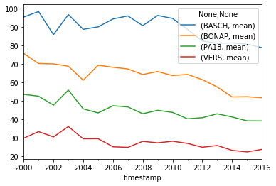

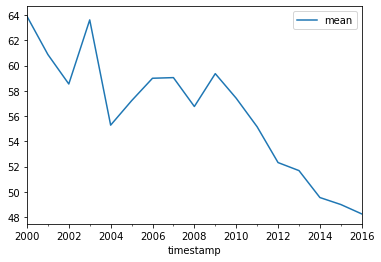

```python
# write your code here

no2.resample('Y').agg(['mean']).plot()

no2.mean(axis=1).resample('Y').agg(['mean']).plot()
```

**EXERCISE**: how does the *typical monthly profile* look like for the different stations?

- Add a 'month' column to the dataframe.
- Group by the month to obtain the typical monthly averages over the different years.

First, we add a column to the dataframe that indicates the month (integer value of 1 to 12):

```python
# write your code here

no2['month'] = pd.DatetimeIndex(no2.index).month
```

Now, we can calculate the mean of each month over the different years:

```python
# write your code here

no2.groupby('month').mean()
no2= no2.drop('month', axis=1)
```

[output not shown]

**EXERCISE**: The typical diurnal profile for the different stations

- Similar as for the month, you can now group by the hour of the day.

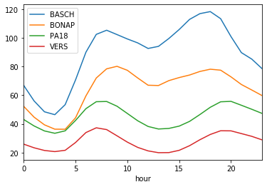

```python
# write your code here


no2['hour'] = pd.DatetimeIndex(no2.index).hour
diurnal = no2.groupby('hour').mean()
diurnal.plot()
```

**EXERCISE**: What is the difference in the typical diurnal profile between week and weekend days for the 'BASCH' station.

- Add a column 'weekday' defining the different days in the week.
- Add a column 'weekend' defining if a days is in the weekend (i.e. days 5 and 6) or not (True/False).
- You can groupby on multiple items at the same time. In this case you would need to group by both weekend/weekday and hour of the day.

Add a column indicating the weekday:

```python
# write your code here

no2['dayofweek'] = pd.DatetimeIndex(no2.index).dayofweek
```

```python
# write your code here
```

Add a column indicating week/weekend

```python
# write your code here
no2['weekend'] = no2['dayofweek'] > 4
no2
```

| timestamp | BASCH | BONAP | PA18 | VERS | hour | dayofweek | weekend |
| --- | --- | --- | --- | --- | --- | --- | --- |
| 2000-01-01 01:00:00 | 108.0 | NaN | 65.0 | 47.0 | 1 | 5 | True |
| 2000-01-01 02:00:00 | 104.0 | 60.0 | 77.0 | 42.0 | 2 | 5 | True |
| 2000-01-01 03:00:00 | 97.0 | 58.0 | 73.0 | 34.0 | 3 | 5 | True |
| 2000-01-01 04:00:00 | 77.0 | 52.0 | 57.0 | 29.0 | 4 | 5 | True |
| ... | ... | ... | ... | ... | ... | ... | ... |
| 2016-12-31 20:00:00 | 73.0 | 51.0 | 49.0 | 20.0 | 20 | 5 | True |
| 2016-12-31 21:00:00 | 61.0 | 51.0 | 48.0 | 16.0 | 21 | 5 | True |
| 2016-12-31 22:00:00 | 57.0 | 49.0 | 45.0 | 14.0 | 22 | 5 | True |
| 2016-12-31 23:00:00 | 51.0 | 47.0 | 45.0 | 12.0 | 23 | 5 | True |

149039 rows × 7 columns

Now we can groupby the hour of the day and the weekend (or use `pivot_table` - check it in the documentation):

```python
# write your code here
no2.groupby(['weekend', 'hour']).mean()
```

| weekend | hour | BASCH | BONAP | PA18 | VERS | dayofweek |
| --- | --- | --- | --- | --- | --- | --- |
| False | 0 | 62.683270 | 49.385498 | 41.966667 | 25.601584 | 2.000000 |
|  | 1 | 51.150107 | 41.151063 | 37.160479 | 22.988806 | 2.000000 |
|  | 2 | 44.088698 | 36.148094 | 33.933945 | 21.275548 | 2.000000 |
|  | 3 | 43.542551 | 33.898973 | 32.919567 | 20.782081 | 2.000000 |
| ... | ... | ... | ... | ... | ... | ... |
| True | 20 | 94.654967 | 67.675971 | 51.512038 | 30.216405 | 5.499718 |
|  | 21 | 85.394768 | 64.085003 | 49.662948 | 29.023324 | 5.499718 |
|  | 22 | 81.529132 | 60.684242 | 47.879037 | 28.166181 | 5.499718 |
|  | 23 | 76.563615 | 57.952005 | 45.887845 | 26.662194 | 5.499718 |

48 rows × 5 columns

```python
# write your code here

pd.pivot_table(no2, values=['BASCH', 'BONAP', 'PA18', 'VERS'], index=['weekend', 'hour'], aggfunc=np.mean)
```

| weekend | hour | BASCH | BONAP | PA18 | VERS |
| --- | --- | --- | --- | --- | --- |
| False | 0 | 62.683270 | 49.385498 | 41.966667 | 25.601584 |
|  | 1 | 51.150107 | 41.151063 | 37.160479 | 22.988806 |
|  | 2 | 44.088698 | 36.148094 | 33.933945 | 21.275548 |
|  | 3 | 43.542551 | 33.898973 | 32.919567 | 20.782081 |
| ... | ... | ... | ... | ... | ... |
| True | 20 | 94.654967 | 67.675971 | 51.512038 | 30.216405 |
|  | 21 | 85.394768 | 64.085003 | 49.662948 | 29.023324 |
|  | 22 | 81.529132 | 60.684242 | 47.879037 | 28.166181 |
|  | 23 | 76.563615 | 57.952005 | 45.887845 | 26.662194 |

48 rows × 4 columns

```python
# write your code here
```

```python
# write your code here
```

**EXERCISE**: What are the number of exceedances of hourly values above the European limit 200 µg/m3 ? Count the number of exceedances of hourly values above the European limit 200 µg/m3 for each year and station after 2005. Make a barplot of the counts. Add an horizontal line indicating the maximum number of exceedances (which is 18) allowed per year?  
Hints:

- Create a new DataFrame, called `exceedances`, (with boolean values) indicating if the threshold is exceeded or not
- Remember that the sum of True values can be used to count elements. Do this using groupby for each year.
- Adding a horizontal line can be done with the matplotlib function `ax.axhline`.

```python
# re-reading the data to have a clean version
no2 = pd.read_csv('data/20000101_20161231-NO2.csv', sep=';', skiprows=[1], na_values=['n/d'], index_col=0, parse_dates=True)
```

```python
# write your code here

exceedances = no2 > 200

exceedances['year'] = pd.DatetimeIndex(no2.index).year
exceedances = exceedances[exceedances['year'] >= 2005]
```

```python
# group by year and count exceedances (sum of boolean)
# write your code here

exceedances.groupby('year').sum()
```

| year | BASCH | BONAP | PA18 | VERS |
| --- | --- | --- | --- | --- |
| 2005 | 68.0 | 0.0 | 1.0 | 0.0 |
| 2006 | 101.0 | 13.0 | 7.0 | 0.0 |
| 2007 | 101.0 | 23.0 | 0.0 | 0.0 |
| 2008 | 35.0 | 2.0 | 0.0 | 0.0 |
| ... | ... | ... | ... | ... |
| 2013 | 27.0 | 2.0 | 0.0 | 0.0 |
| 2014 | 16.0 | 1.0 | 0.0 | 0.0 |
| 2015 | 36.0 | 0.0 | 0.0 | 0.0 |
| 2016 | 22.0 | 1.0 | 0.0 | 0.0 |

12 rows × 4 columns

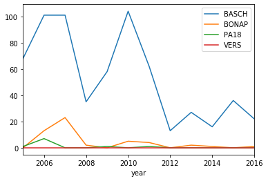

```python
# write your code here

ex_plot = exceedances.groupby('year').sum()

ex_plot.plot()
```

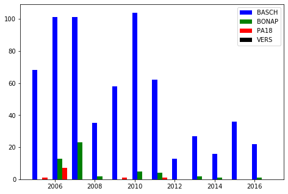

```python
fig = plt.figure()
ax = fig.add_axes([0,0,1,1])

ax.bar(ex_plot.index, ex_plot['BASCH'], color = 'b', width = 0.25)
ax.bar(ex_plot.index + 0.25, ex_plot['BONAP'], color = 'g', width = 0.25)
ax.bar(ex_plot.index + 0.5, ex_plot['PA18'], color = 'r', width = 0.25)
ax.bar(ex_plot.index + 0.75, ex_plot['VERS'], color = 'black', width = 0.25)
ax.legend(labels=['BASCH', 'BONAP', 'PA18', 'VERS'])
```

# 9. What I didn't talk about

- Concatenating data: `pd.concat`
- Merging and joining data: `pd.merge`
- Reshaping data: `pivot_table`, `melt`, `stack`, `unstack`
- Working with missing data: `isnull`, `dropna`, `interpolate`, ...
- ...

## Further reading

- Pandas documentation: http://pandas.pydata.org/pandas-docs/stable/
- Tutorials (many good online tutorials!)
  - https://github.com/jorisvandenbossche/pandas-tutorial
  - https://github.com/brandon-rhodes/pycon-pandas-tutorial